# Classification and regression trees for linguistic analysis

Jason Grafmiller

June 6, 2018

In this tutorial, we’ll go over the basics of how to use **classification**, **regression**, and **conditional inference trees**, more generally referred to as decision tree models. The basic methods have been around for a while (see Breiman 1998[1984]), but they are relatively new to linguistics. One of the first papers to utilize this technique, and the related technique of **random forests**, in linguistics was Tagliamonte & Baayen (2012), but the tree & forest method has been gaining ground as a useful alternative to other methods such as regression in recent years (Bernaisch et al. 2014; Szmrecsanyi et al. 2016a; Tagliamonte et al. 2016).

**Let’s get started!**

## Setup

Before we get started, let’s load our basic libraries.

```r
# basic data wrangling & plotting
library(tidyverse)
library(reshape2)
library(gridExtra)

# for the trees
library(rpart)
library(partykit)
```

## What are classification and regression trees?

Decision tree models like classification and regression trees (**CARTs**) are similar in spirit to regression in that they are used to predict a response $Y$ from a set of predictors $X_1, X_2,...,X_n$. There are several packages in R for computing CARTs and we will briefly look at a couple of them here, namely the `rpart` and `partykit` packages.

There are generally two types of decision trees:

- **Classification trees** are used when you want to predict a categorical response. That is, the dependent variable can be assigned to 2 or more discrete classes, values, or labels.
- **Regression trees** are used when you want to predict a continuous response. That is, the dependent variable can take any of an infinite range of numerical values.

One of the major differences between tree models and standard regression models is that the latter are ‘global’ models, in the sense that the prediction formula is assumed to hold over the entire data space. This means that in the simple case of a regression formula without any interactions,

$$y = \beta_1x_1 + \beta_2x_2 + \beta_3x_3$$

the effect of predictor $x_1$ on the response $y$ is assumed to be the same no matter what the values of predictors $x_2$ and $x_3$ may be. This is not so with tree models.

The idea behind tree models is to divide the data space into smaller and smaller non-overlapping partitions, to which simpler models can be applied. Tree models use a top-down approach, in which we begin at the top of the tree where all observations are included in a single region and successively split the data space into new branches (subregions) down the tree. Most tree algorithms are [‘greedy’](https://en.wikipedia.org/wiki/Greedy_algorithm) in that they consider only the best split *for the current region of the data*. That is, they don’t care about what splits have come before, or what splits may come after the current node. Splitting continues until some threshold is reached, and how that threshold is defined can have a major impact on the results.

## Terminology

A bit of terminology:

- **Nodes**: Points at which a splitting decision is made. Each node represents a (sub)section of the dataset. The **Root node** is the node at the top of the tree which represents the entire sample prior to any splitting.
- **Branches**: Subsections of the entire tree (a,so called **sub-trees**)
- **Leaves / Terminal nodes**: Nodes at the bottom of the tree where no further split is made.
- **Parent / Child nodes**: Super- and subordinate nodes are referred to as **parent** and **child** nodes respectively.

In all decision trees, the leaves of the tree (terminal nodes) give us predictions about our response for the subregion of the dataset that the leaves represent.

- For **classification trees**, the leaves of the tree (terminal nodes) give us predictions about which class is mostly likely for that subregion of the data. This is measured simply as the class with the most observations, i.e. the class that makes up the largest proportion of the data.
- For **regression trees**, the prediction is just the mean value of the response for the observations in a given subregion. So if a data point falls into that region, our prediction for its response will be the average response in that region.

For this tutorial, we will focus on methods that use **binary splits**, though thereare methods for producing trees with more than two branches, e.g. with `J48()` in the `RWeka` package.

## Splitting criteria

One of the most important factors affecting the accuracy of tree models is the method that the tree-growing algorithm uses to determine where and when to make a split. Remember, the idea is to find the “best” split at any given point, so the question becomes, how to determine the “best” split.

Decision trees use different algorithms to find the best split, and I’ll briefly mention the most common here. But first, some more terminology…

When talking about trees, we often talk about the homogeneity or **purity** of a given region of the data with respect to the distribution of the response variable. If you consider the plots below, it’s fairly easy to see which plot is the most homogeneous or “pure”.

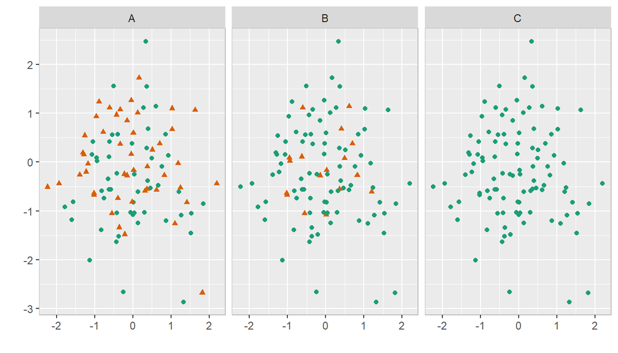

Conversely, we can describe a region in terms of its **impurity**, in which case we can think of splitting a node as an attempt to partition the data in a manner that minimizes the impurity in the resulting subsets. Splitting is thus driven by the goal of **impurity reduction**. The goal is to divide the data up into subsets that are as homogenous or “pure” as we can possibly get based on the values of our predictors.

## Datasets

For for classification trees we’ll use two datasets from studies of syntactic alternations in English.

```r
# These two are big files so I have saved them as more efficient .rds files.
# These are not readable with other programs, e.g. Excel, but they take up
# less space and are quicker to load.
gens <- readRDS("data/written_genitives.rds") %>% as.tibble
rels <- readRDS("data/object_relatives.rds") %>% as.tibble
# read from usual .csv file
english <- read.csv("data/english_word_decisions.csv") %>% as.tibble
```

### Dataset `written_genitives.rds`

This is a dataset of English genitive constructions taken from the Brown and Frown corpora of written US English in the 1960s and 1990s, respectively. It contains all genitive tokens (of-gentives, as in *the best interest of both governments*; and the s-genitive, as in *both governments’ best interest*) found in five different fiction and nonfiction genres. This data was collected and annotated to investigate the infuence of a number of factor on writers’ choice of genitive construction (see Grafmiller 2014).

1. *the president’s assertion* [*s*-genitive]
2. *the contour of her face* [*of*-genitive]

The English genitive alternation is known to be correlated with a number of features, including…

- `Possessor.Animacy.Bin` the animacy of the possessor
- `Possessor.Word.Count` & `Possessum.Word.Count` the length in words of the possessor and possessum
- `Final.Sibilant` the presence of a sibilant at the end of the possessor (*Bush’s prestige*)
- `Semantic.Relation` semantic relation between possessor and possessum (kinship, ownership, body-part, etc.)
- `TypeTokenRatio` the type-token ratio of the local context
- `Genre` the genre of the text (Newspaper, academic, fiction, etc.)
- `Corpus` the corpus the token was taken from

```r
# inspect the data
head(gens)
```

```
# A tibble: 6 x 35
  Token.ID Corpus Text.ID Genre Comments Type  Semantic.Relation
  <fct>    <chr>  <fct>   <chr> <fct>    <fct> <fct>
1 1        Frown  A01     Press ""       of    OTH
2 2        Frown  A01     Press ""       s     OTH
3 3        Frown  A01     Press ""       s     OTH
4 4        Frown  A01     Press ""       s     OTH
5 5        Frown  A01     Press ""       of    OTH
6 6        Frown  A01     Press ""       of    OTH
# ... with 28 more variables: Whole.Genitive <chr>, Whole.Sentence <chr>,
#   Possessor <chr>, Possessor.Head <fct>,
#   Possessor.Expression.Type <chr>, Final.Sibilant <fct>,
#   Possessum <fct>, Possessum.Head <fct>, Possessor.Animacy <fct>,
#   Possessum.Animacy <fct>, Possessor.Givenness <fct>,
#   Possessor.Word.Count <int>, Possessum.Word.Count <int>,
#   Possessor.Syl.Count <fct>, Possessum.Syl.Count <fct>,
#   Prior.Genitive <chr>, Possessor.Animacy.Bin <fct>,
#   Possessum.Animacy.Bin <fct>, Semantic.Relation.Bin <chr>,
#   TypeTokenRatio <dbl>, PossessorFreq <int>, PossessumFreq <int>,
#   PossessorTextFreq <dbl>, PossessumTextFreq <fct>,
#   PossessorLogTFreq <dbl>, PossessumLogTFreq <dbl>,
#   Prior.Genitive.Bin <fct>, Genre.Bin <fct>
```

### Dataset `object_relatives.rds`

This is a dataset of English relative clauses taken from the Brown and Frown corpora of written US English, as well as the parallel LOB and FLOB corpora of written UK English (in all genres). This data was collected to investigate the influence of various factors on the choice relativizer, i.e. *that* vs. *which* vs. *ZERO* (see Hinrichs et al. 2015; Grafmiller et al. 2016).

3. *a doctrine **that** nobody either does or need hold*
4. *mistakes **which** others manage to avoid*
5. *the boundary conditions ___ we impose*

The choice among relative pronouns in English is known to be correlated with a number of features, including…

- `RCLn` the length of the relative clause
- `antLN` the length of the antecedent NP (both this and the above are related to the complexity of the RC context)
- `antPOS` the part of speech of the antecedent
- `antNum` the number of the antecedent
- `precRel` prior use of a particular pronoun (‘structural persistence/priming’)
- `variety` variety (AmE or BrE)
- `time2` time period (1961 or 1991)

Like the genitive case, the goal of these studies was to investigate the factors that co-determine/correlate with the choice of relativizer, particularly *that* vs. *which* vs. *ZERO*

```r
# inspect the data
head(rels)
```

```
# A tibble: 6 x 46
   item corpus variety  time file   category genre rel   which that  zero
  <int> <fct>  <fct>   <int> <fct>  <fct>    <fct> <fct> <fct> <fct> <fct>
1  2995 Brown  AmE      1961 brown~ J        lear~ ZERO  no    no    ZERO
2  2994 Brown  AmE      1961 brown~ J        lear~ ZERO  no    no    ZERO
3  2996 Brown  AmE      1961 brown~ J        lear~ ZERO  no    no    ZERO
4  2992 Brown  AmE      1961 brown~ J        lear~ ZERO  no    no    ZERO
5  3125 FLOB   BrE      1991 FLOB_~ J        lear~ WHICH WHICH no    no
6  3128 FLOB   BrE      1991 FLOB_~ J        lear~ THAT  no    THAT  no
# ... with 35 more variables: precRel <fct>, distPrecRel <int>,
#   nested <fct>, relFct <fct>, antPOS <fct>, antNum <int>, antLN <int>,
#   antGiven <fct>, antDefinite <fct>, antFreq <dbl>, antHeadToRC <int>,
#   RCLn <int>, levyJaeger <chr>, TTR <dbl>, meanWordLen <dbl>,
#   meanSentLen <dbl>, stranding <dbl>, splitInf <dbl>, asIfThough <dbl>,
#   passives <dbl>, passiveActiveRatio <dbl>, shallWill <dbl>,
#   nouniness <dbl>, nounVerbRatio <dbl>, persPronouns <dbl>,
#   subordConjs <dbl>, animacy <fct>, antHead <chr>, adjacency <fct>,
#   construction <chr>, antNum2 <fct>, antPOS2 <fct>, time2 <fct>,
#   prunedAntHead <fct>, plainText <chr>
```

### Dataset `english.csv`

For regression trees we’ll use a dataset that comes from the `languageR` package (Baayen 2008) and gives mean visual lexical decision latencies and word naming latencies for 2284 monomorphemic English nouns and verbs, averaged for old and young subjects, with various predictor variables (see Baayen et al. 2006 for more details).

You can find more information about this dataset by consulting the documentation with `?languageR::english`. There are a few columns we will be looking at in particular:

- `RTlexdec` log response time in visual lexical decision task
- `Familiarity` subjective familiarity ratings from pilot study
- `Word` factor with the target word
- `WordCategory` the word categories N (noun) and V (verb)
- `WrittenFrequency` the written frequency of the word
- `LengthInLetters` length of the word in letters
- `AgeSubject` age group of the experimental participant (young vs old)

```r
# check out the data
head(english)
```

```
# A tibble: 6 x 36
  RTlexdec RTnaming Familiarity Word   AgeSubject WordCategory
     <dbl>    <dbl>       <dbl> <chr>  <chr>      <chr>
1     6.54     6.15        2.37 doe    young      N
2     6.40     6.25        4.43 whore  young      N
3     6.30     6.14        5.6  stress young      N
4     6.42     6.13        3.87 pork   young      N
5     6.45     6.20        3.93 plug   young      N
6     6.53     6.17        3.27 prop   young      N
# ... with 30 more variables: WrittenFrequency <dbl>,
#   WrittenSpokenFrequencyRatio <dbl>, FamilySize <dbl>,
#   DerivationalEntropy <dbl>, InflectionalEntropy <dbl>,
#   NumberSimplexSynsets <dbl>, NumberComplexSynsets <dbl>,
#   LengthInLetters <int>, Ncount <int>, MeanBigramFrequency <dbl>,
#   FrequencyInitialDiphone <dbl>, ConspelV <int>, ConspelN <dbl>,
#   ConphonV <int>, ConphonN <dbl>, ConfriendsV <int>, ConfriendsN <dbl>,
#   ConffV <dbl>, ConffN <dbl>, ConfbV <dbl>, ConfbN <dbl>,
#   NounFrequency <int>, VerbFrequency <int>, CV <chr>, Obstruent <chr>,
#   Frication <chr>, Voice <chr>, FrequencyInitialDiphoneWord <dbl>,
#   FrequencyInitialDiphoneSyllable <dbl>, CorrectLexdec <int>
```

## Classification trees

**Classification trees** are similar to logistic regression in that they are used to predict the probability of a set of two or more possible responses or outcomes. This is perhaps the most intuitive use of tree models.

### A simple tree with `rpart`

Let’s start by fitting a simple classification tree model and plot it. We’ll consider the effect of possessor animacy (as a binary variable) and final sibilant on the choice of genitive variant.

First we’ll define the formula for quick calling. Here we are trying to predict the **Type** of genitive construction based on whether the possessor in animate or not (**Possessor.Animacy.Bin**), and whether the possessor ends in a sibilant sound (**Final.Sibilant**).

```r
gen_fmla1 <- Type ~ Possessor.Animacy.Bin + Final.Sibilant
```

We’ll start with the `rpart()` function for creating trees, found in the `rpart` package. We’ll fit the model and plot it. See `?plot.rpart` for help.

```r
gen_rpart1 <- rpart(gen_fmla1, data = gens, method = "class")
```

We’ll plot the tree and tell it to add text to all nodes indicating the number of tokens in that node (`use.n`).

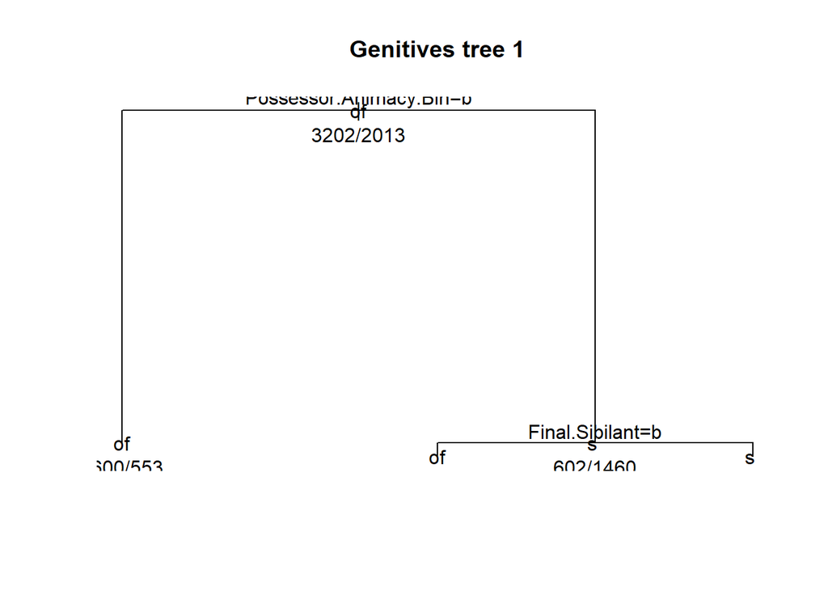

```r
plot(gen_rpart1)
text(gen_rpart1, all = T, use.n = TRUE)
title("Genitives tree 1")  # add a title
```

The default splitting criterion in `rpart` is “gini”, but We can try to use a different information theoretic criteron (generally with binary outcomes the two methods almost always yield the same results).

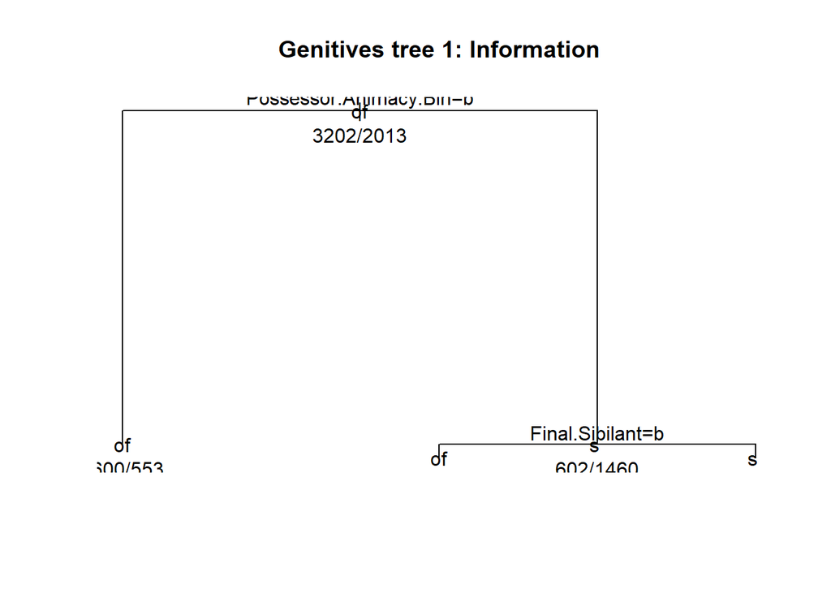

```r
gen_rpart1b <- rpart(gen_fmla1, data = gens, method = "class", parms = list(split = "information"))

# plot the tree.
plot(gen_rpart1b)
text(gen_rpart1b, all = T, use.n = TRUE)
title("Genitives tree 1: Information")
```

### Making nice(r) plots

Unfortunately the basic plotting functions for `rpart` are rather ugly and unhelpful, but there are ways to make the output nicer.

One way is to adjust some of the plotting parameters. We can check those parameters in the documentation.

```r
`?`(plot.rpart)
```

We’ll set the branches to have uniform length, with a slight slant, and we’ll add a margin of whitespace around the plot.

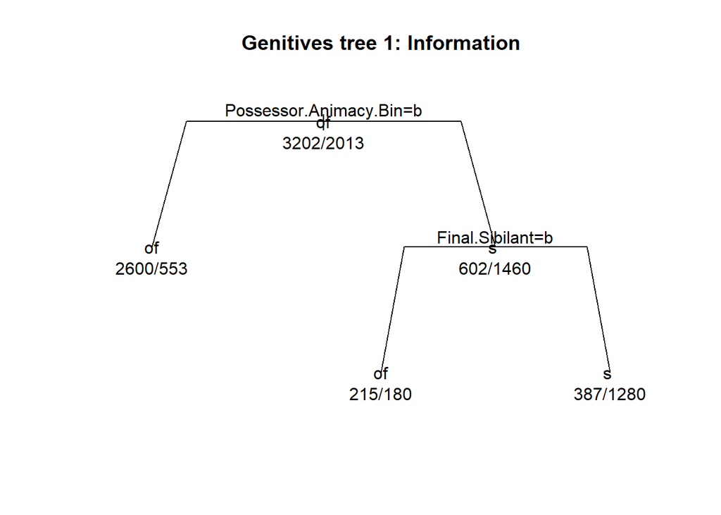

```r
plot(gen_rpart1b, uniform = T, branch = 0.8, margin = 0.1)
text(gen_rpart1b, all = T, use.n = TRUE)
title("Genitives tree 1: Information")
```

Still not optimal, but better.

Another way is to convert the tree to a party object with `as.party()` from the `partykit` package (more on this below). This is my preferred method.

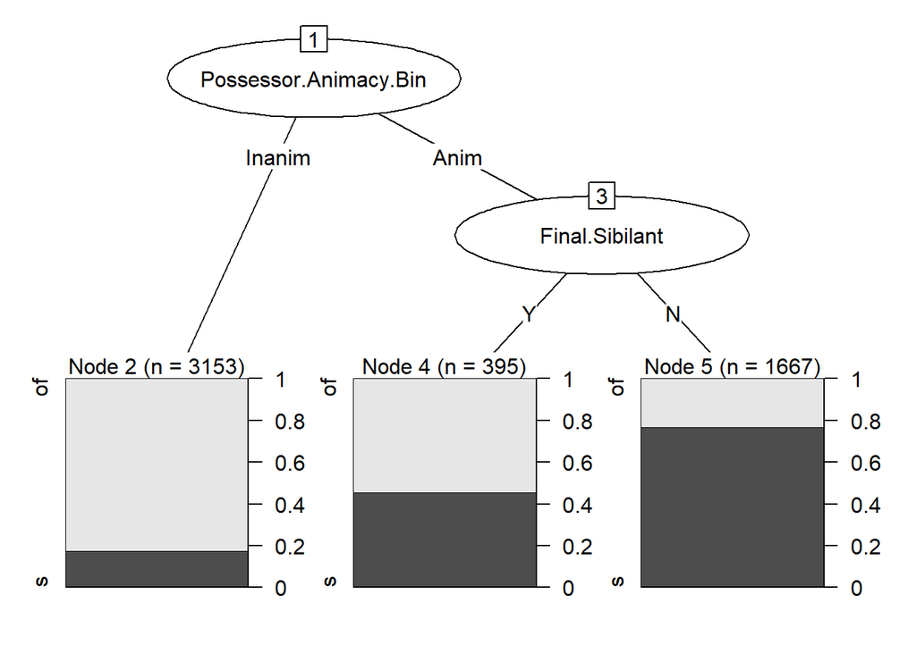

```r
# create a party plot and pass it along with the pipe operator
as.party(gen_rpart1) %>% plot
```

This output is much clearer.

We see that initially, the best split is between animate and inanimate possessors. Then, we look at the corresponding subsets and see that the presence of a final sibilant also has an effect. However, the it seems that the effect is limited to only the subset of the data in which the possessor is animate, as indicated by the presence of a split on the right, but not on the left.

Finally, the `rattle` package makes nice graphs as well with the `fancyRpartPlot()` function. (You’ll need to have this package installed…)

[figure not shown]

```r
rattle::fancyRpartPlot(gen_rpart1)
```

I still prefer the `partykit` plots, but this is not bad.

### A simple tree with `partykit`

Now we’ll move on to a different tree fitting method using `partykit`. This package contains the function `ctree()` for **Conditional Inference Tree**. Ctrees are related to traditional classification and regression trees, except that the method offers certain advantages over the methods used in `rpart`, which tend to favor variables that have many possible splits or many missing values (Hothorn et al. 2006).

Let’s try a simple ctree for the first genitives formula…

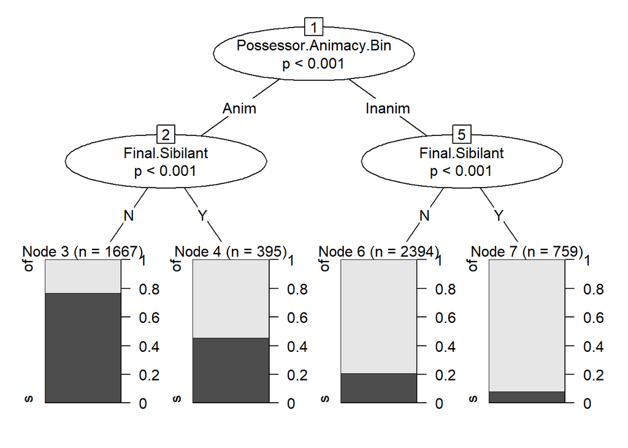

```r
gen_ctree1 <- ctree(gen_fmla1, data = gens)
plot(gen_ctree1)
```

We see from Node 1 that initially, the best split is between animate and inanimate possessors. Then, we look at the corresponding subsets and see that the presence of a final sibilant also has an effect. BUt already we can see the differencesin the splitting methods. Before, the rpart tree had a **Final.Sibilant** based split only with the animate subtree. But the ctree shows an additional split within the inanimate subtree as well.

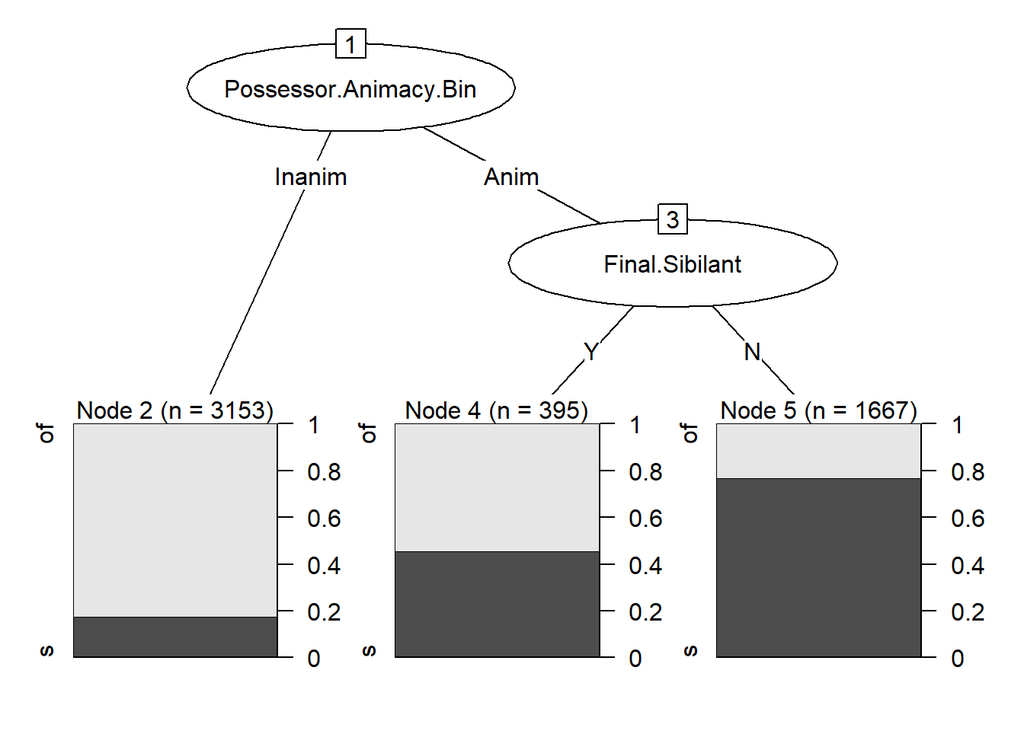

```r
# rpart tree
as.party(gen_rpart1) %>% plot
```

### Predicting *N* > 2 response classes

A particularly nice thing about decision tree modesl is that they easily allow us to model multinomial responses.

Here we’ll try to predict English relativizers with a simplified model, looking at only the object RCs (*the book that/which/∅ you wrote*).

For first pass, we can simply look at the change in relativzer use over time and across US and UK English.

```r
# rpart
rel_rpart1 <- rpart(rel ~ variety + time2, rels, method = "class")
plot(rel_rpart1)
```

When we try to plot the tree, we get an error. This tells us that rpart was not able to create a decision tree from these predictors. Changing the splitting criteron doesn’t affect this either.

```r
# rpart
rel_rpart1b <- rpart(rel ~ variety + time2, rels, method = "class", parms = list(split = "information"))
plot(rel_rpart1b)
```

If we plot the distributions of the relativizers we can see that there is in fact a big drop in the use of *which* in US English over time.

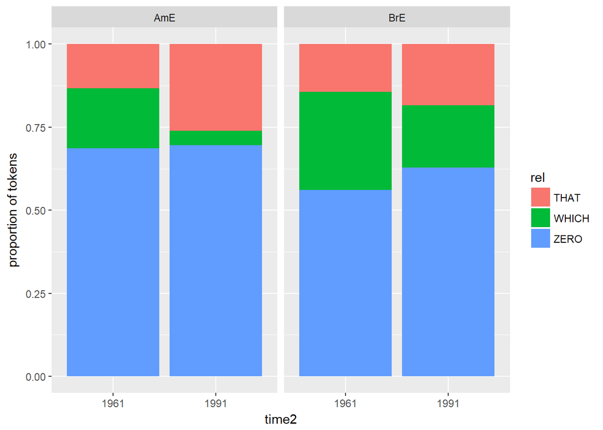

```r
ggplot(rels, aes(time2, fill = rel)) + geom_bar(position = "fill") + facet_wrap(~variety,
    ncol = 2) + labs(y = "proportion of tokens")
```

Presumably the model should capture this, but it doesn’t. If we add a couple more predictors for the length of the relative clause `RCLn`, and the length of the antecedent `antLN` we can get some results.

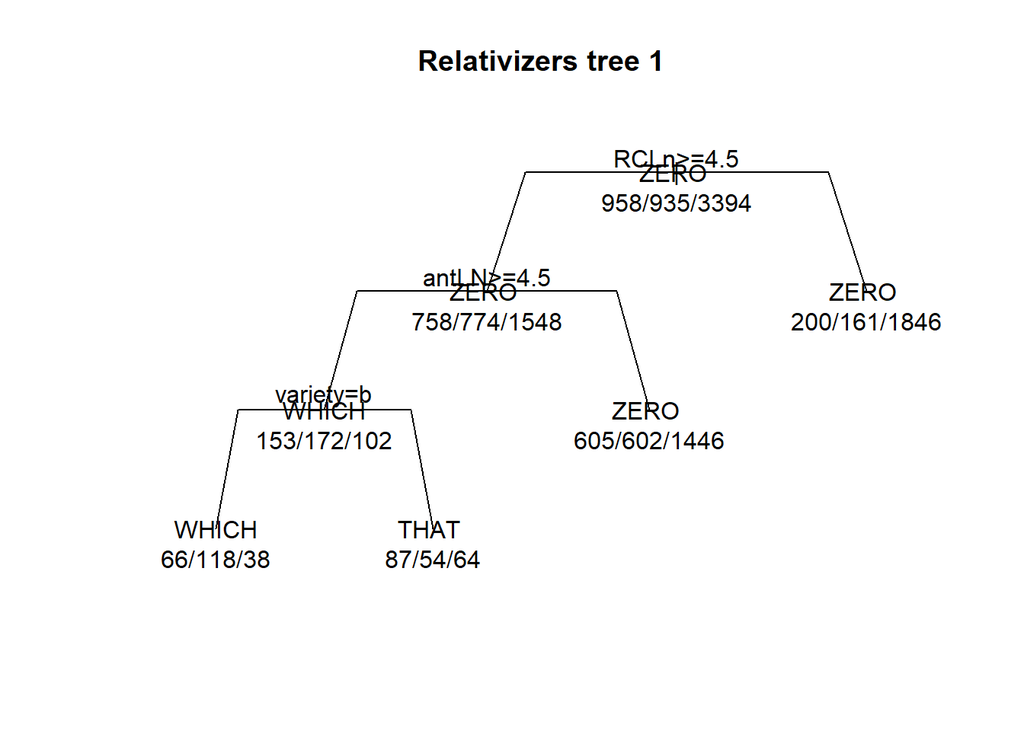

```r
rel_rpart2 <- rpart(rel ~ variety + time2 + RCLn + antLN, rels)
plot(rel_rpart2, uniform = T, branch = 0.8, margin = 0.1)
text(rel_rpart2, all = T, use.n = TRUE)
title("Relativizers tree 1")
```

The numbers on the leaves show the respective counts for the 3 different relativizer types.

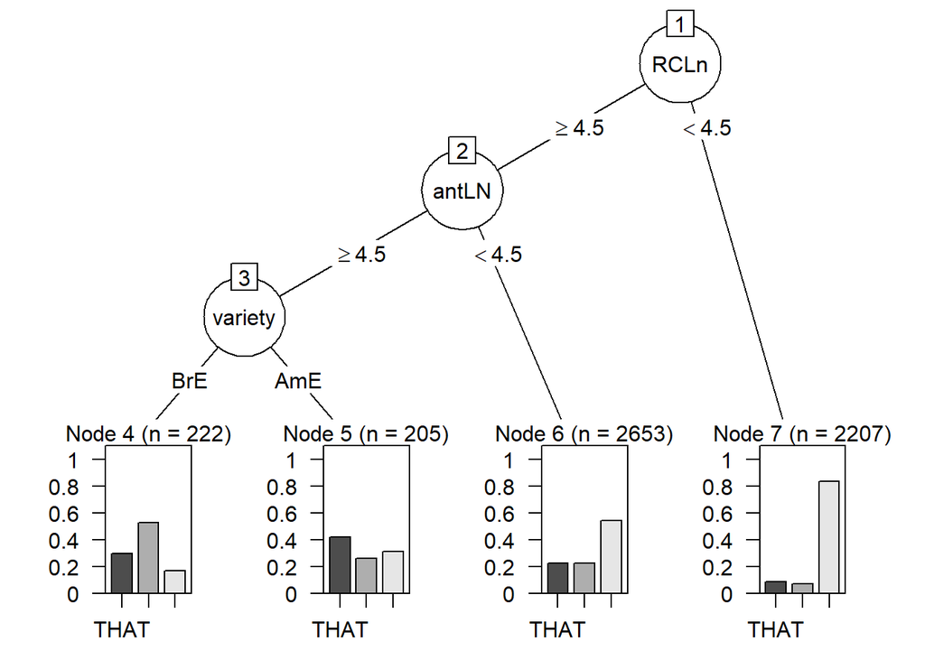

```r
as.party(rel_rpart2) %>% plot()
```

Now we can really see what’s going on. The splits are much clearer, and our leaves now show the *proportions* of relativizer types in each subset, which is realyl what we want to know more than the raw counts.

The `rattle` package also has nice visualization.

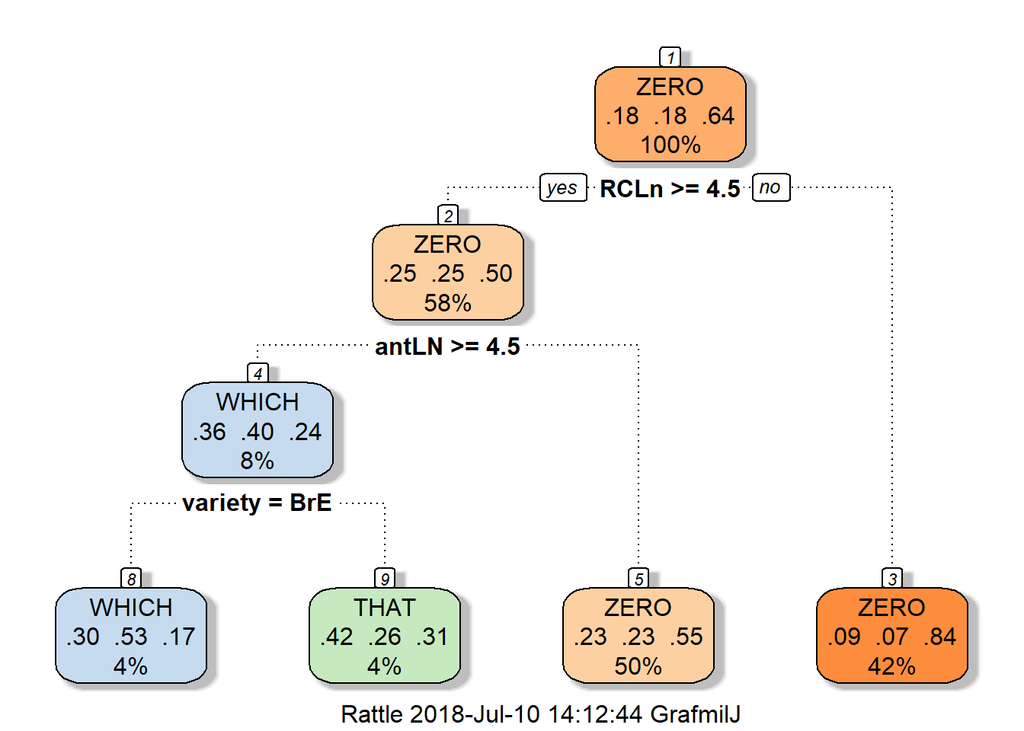

```r
rattle::fancyRpartPlot(rel_rpart2)
```

But let’s go back to the first relativzer tree attempt, and this time we’ll use `ctree()` and see what happens.

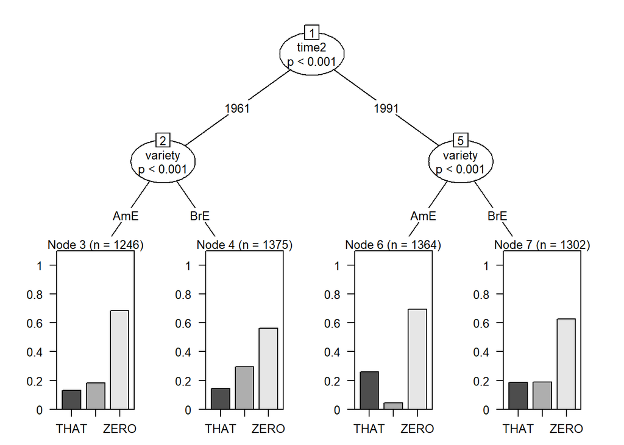

```r
# rpart
rel_ctree1 <- ctree(rel ~ variety + time2, rels)
plot(rel_ctree1, gp = gpar(cex = 0.8))
```

Here we can see that while the impurity reduction criteria yielded no splits, the conditional inference method did indeed detect strong associations among the predictors and the response. This is very much what we would expect just from eyeballing the distrinbutions of relativizers across time and variety.

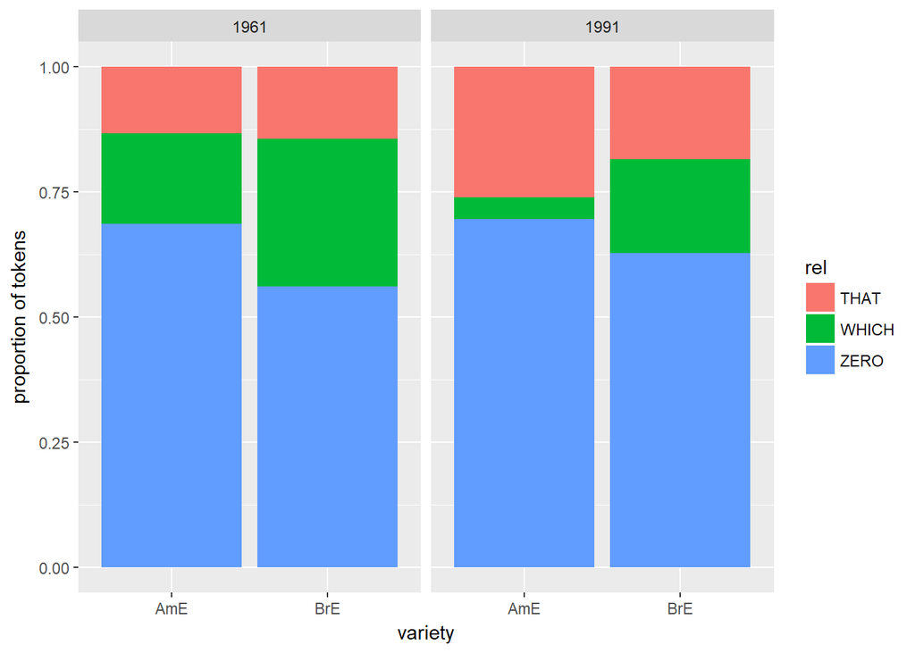

```r
ggplot(rels, aes(variety, fill = rel)) + geom_bar(position = "fill") + facet_wrap(~time2,
    ncol = 2) + labs(y = "proportion of tokens")
```

This is a nice illustration of how the choice fo splitting method can dramatically influence the resulting trees. IN my experience, conditional inference trees will find more splits than trees using gini or information gain measures, and often those splits are intuitively reasonable. This is one reason I prefer `ctree()` over `rpart()`.

[figure not shown]

```r
rel_ctree2 <- ctree(rel ~ variety + time2 + RCLn + antLN, rels)
plot(rel_ctree2, gp = gpar(cex = 0.8))
```

### More complex trees

That was easy. Now let’s try to break stuff.

Take the formula below for genitive choice using more predictors motivated by prior research. These are mostly categorical predictors, so the model should be relatively simple (we hope).

```r
gen_fmla2 <- Type ~ Possessor.Animacy.Bin + Final.Sibilant + Possessor.Word.Count +
    Semantic.Relation.Bin + Possessor.Expression.Type + Genre + Corpus + Possessum.Word.Count +
    PossessorTextFreq + PossessumTextFreq + Prior.Genitive
```

Now we fit a tree using this formula.

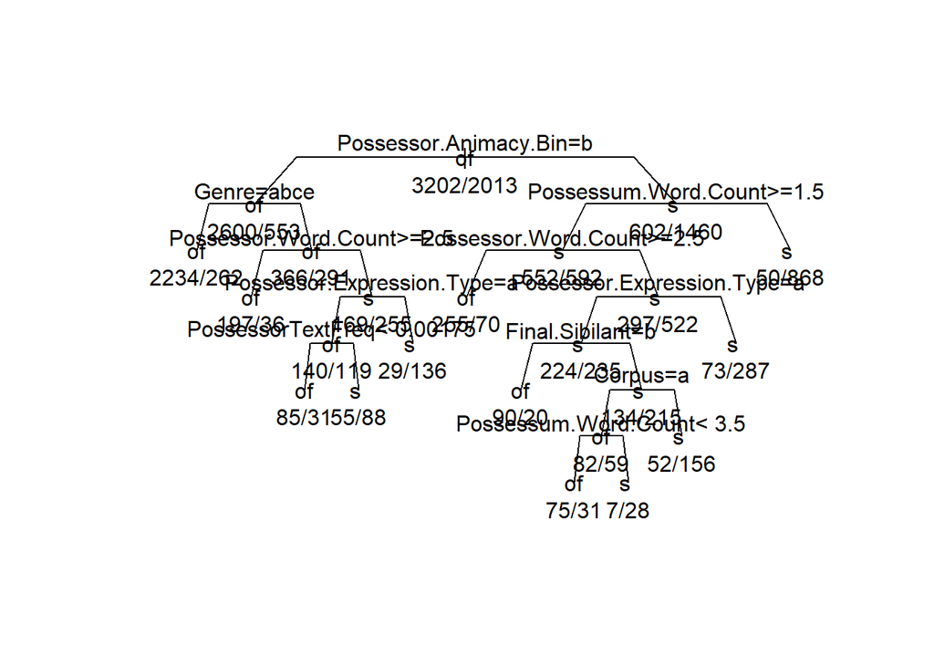

```r
gen_rpart2 <- rpart(gen_fmla2, data = gens)
plot(gen_rpart2, uniform = T, branch = 0.8, margin = 0.1)
text(gen_rpart2, all = T, use.n = TRUE)
```

Yeahhhh.. That’s not very helpful. Try with `partykit`…

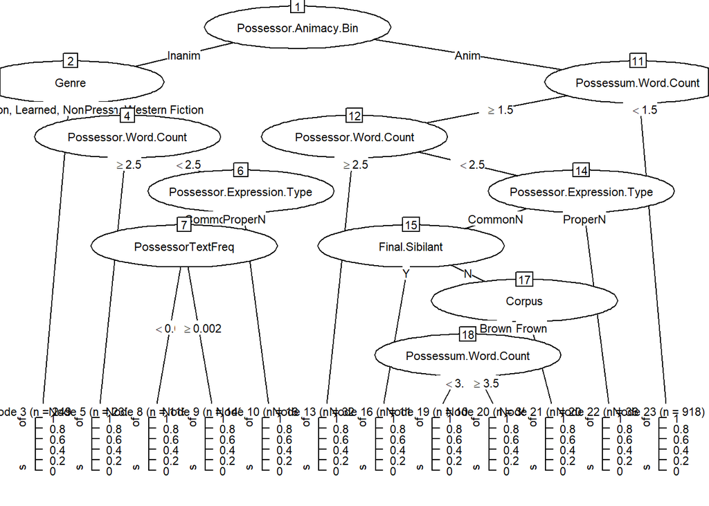

```r
as.party(gen_rpart2) %>% plot(gp = gpar(cex = 0.7))  # shrink the text size
```

Not very helpful. What about a `ctree()`?

```r
gen_ctree2 <- ctree(gen_fmla2, data = gens)
```

An error…? The problem is that before using `ctree()` we need to make sure the columns of the dataframe for our predictors are in the necessary format. `ctree()` doesn’t work with character vectors, so we’ll need to convert the relevant columns to factors.

```r
factors <- c("Possessor.Animacy.Bin", "Final.Sibilant", "Semantic.Relation.Bin",
    "Possessor.Expression.Type", "Genre", "Corpus", "Prior.Genitive")
gens[factors] <- lapply(gens[factors], as.factor)
```

Now try it.

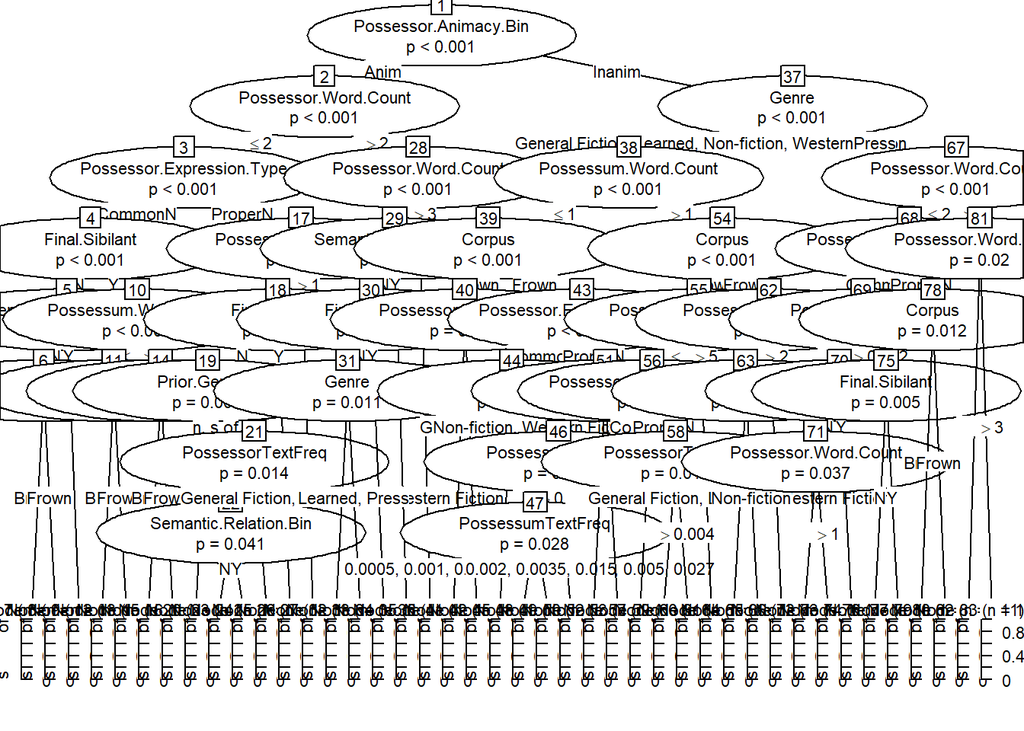

```r
gen_ctree2 <- ctree(gen_fmla2, data = gens)
plot(gen_ctree2, gp = gpar(cex = 0.7))
```

O.M.G. This is useless. We can’t even read it, let alone try to interpret it.

Crazy trees like this are probably a sign that our tree may not be the best model for the purposes of learning something about the larger population our data is sampled from. The problem is that the tree-building algorithm will look for any and all possible splits in the data, regardless of whether those divisions are likely to be replicated if we were to take different samples of genitive constructions. This is the problem of **overfitting**: our tree model is too finely tuned to our specific dataset, thus it does not likely represent a good model of genitive variation *in general*. We’ll come back to what to do about this in a moment, but suffice it to say, we can’t just unthinkingly plug formulas and data into a function and get meaningful results…

But let’s stop for a moment and look at regression trees.

## Regression trees

With regression trees, the value shown on the leaf nodes is the expected value of the response, i.e. the mean, for the given partition of the data. Here we’ll look at the effects of a number of predictors on lexical decision latencies in a word recognition task. We’ll first consider the age of the subject (**AgeSubject** = ‘old’ or ‘young’),written frequency of the word, and the syntactic category (‘N’ or ‘V’) of the word.

```r
lexdec_fmla1 <- RTlexdec ~ AgeSubject + WordCategory + WrittenFrequency
```

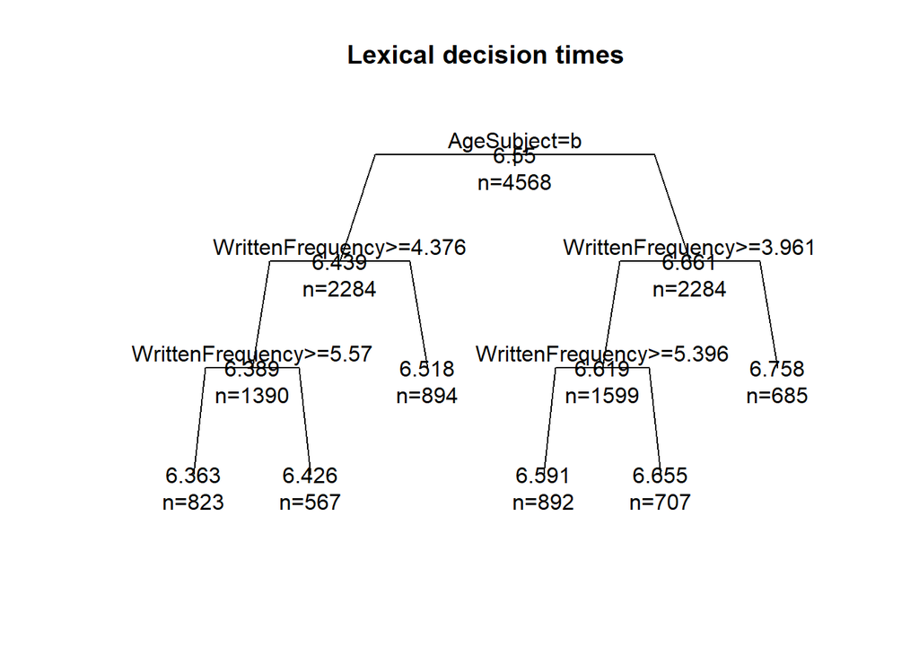

```r
lexdec_rpart1 <- rpart(lexdec_fmla1, data = english)
plot(lexdec_rpart1, uniform = T, branch = 0.8, margin = 0.1)
text(lexdec_rpart1, all = T, use.n = TRUE)
title("Lexical decision times")
```

Try another visualisation.

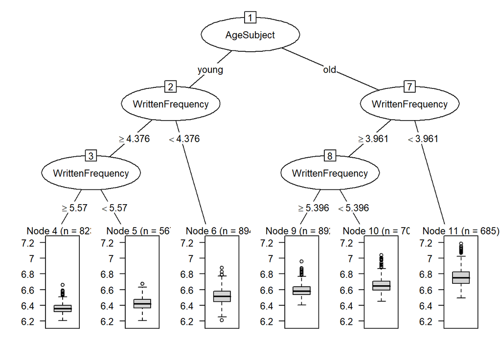

```r
as.party(lexdec_rpart1) %>% plot(gp = gpar(cex = 0.8))
```

The first thing to note is that word category (N or V) doesn’t seem to have much of an effect. There are no category based splits in the tree. The second thing to note is that the leaves of the tree now show boxplots representin the distribution of response times for each subset of the data. This is different from the proportional barplots we saw with classification trees. From these plots, we can see that

1. Younger participants are generally faster than older participants, and
2. The frequency of the word has a clear effect in both age groups–more frequent words are recognized faster regardless of age.

The mean values of the leaves are given in the `rpart` tree. If we take only those cases where the subject is old (the branch on the right) and the `WrittenFrequency` of the word is less 3.961 (Node 11), and then calculate the mean value of **RTlexdec** for that subset of the data, we get 6.758. This is the predicted response time for old subjects responding to words with a written frequency less than 3.961. This corresponds to the value shown in the rightmost node in `lexdec_rpart1`.

```r
subset(english, AgeSubject == "old" & WrittenFrequency < 3.961) %>% .$RTlexdec %>%
    mean()
```

```
[1] 6.758294
```

So what we can conclude from this tree is that age and written frequency seem to have the biggest effect on decision times, while word category has relatively little impact.

We can examine the relationship between these variables with scatter plots, where it’s fairly clear that age has a big effect.

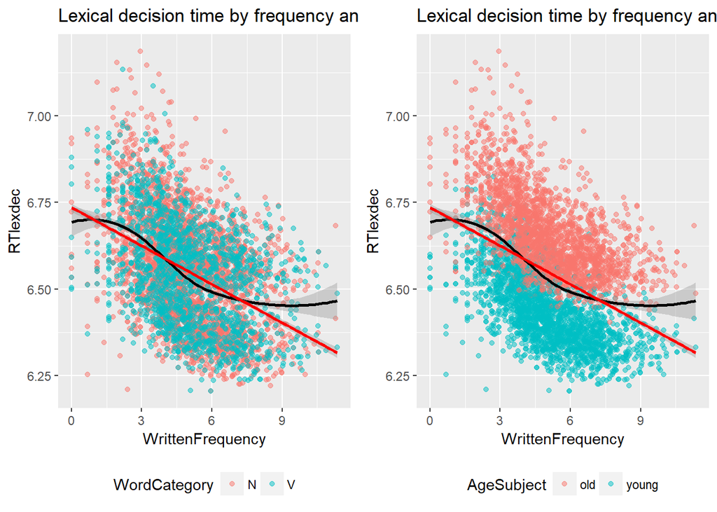

```r
# color by category
p_cat <- ggplot(english, aes(WrittenFrequency, RTlexdec)) + geom_point(aes(col = WordCategory),
    alpha = 0.5) + geom_smooth(method = "loess", color = "black") + geom_smooth(method = "lm",
    color = "red") + ggtitle("Lexical decision time by frequency and category") +
    theme(legend.position = "bottom")

p_age <- ggplot(english, aes(WrittenFrequency, RTlexdec)) + geom_point(aes(col = AgeSubject),
    alpha = 0.5) + geom_smooth(method = "loess", color = "black") + geom_smooth(method = "lm",
    color = "red") + ggtitle("Lexical decision time by frequency and age") +
    theme(legend.position = "bottom")

grid.arrange(p_cat, p_age, ncol = 2)
```

We can just as easily create regression trees with `ctree()`. First check that the columns are in the correct format.

```r
english[, all.vars(lexdec_fmla1)]
```

```
# A tibble: 4,568 x 4
   RTlexdec AgeSubject WordCategory WrittenFrequency
      <dbl> <chr>      <chr>                   <dbl>
 1     6.54 young      N                        3.91
 2     6.40 young      N                        4.52
 3     6.30 young      N                        6.51
 4     6.42 young      N                        5.02
 5     6.45 young      N                        4.89
 6     6.53 young      N                        4.77
 7     6.37 young      N                        6.38
 8     6.27 young      N                        7.16
 9     6.61 young      N                        4.89
10     6.28 young      N                        5.93
# ... with 4,558 more rows
```

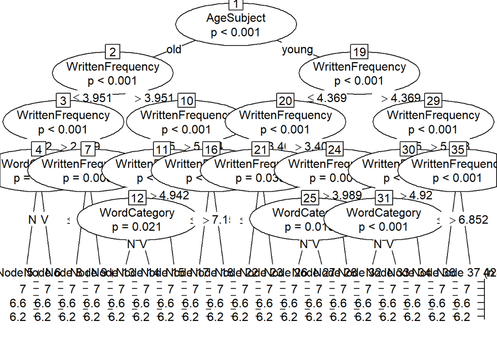

```r
english[c("AgeSubject", "WordCategory")] <- lapply(english[c("AgeSubject", "WordCategory")],
    as.factor)
# make the tree
lexdec_ctree1 <- ctree(lexdec_fmla1, data = english)
plot(lexdec_ctree1)
```

In general, I find regression trees most useful when we have only categorical predictors, and less so when we have lots of continuous predictors. Tree models are good sometimes for identifying inflection points in continuous predictors when the effects are non-linear, but I often find that simple scatterplots are just as effective for exploring relationships among continuous variables.

## Getting model predictions

### With `rpart`

We can obtain the predictions of an `rpart` object like so.

```r
predict(gen_rpart1, type = "class") %>% head
```

```
 1  2  3  4  5  6
of  s  s  s of of
Levels: of s
```

We specify `type = "class"` to give us the predicted classes, but the default of the `predict()` function for classification trees returns a matrix of predicted probabilities of the response classes for each observation. We’ll generate thsi and convert it to a dataframe to which we’ll add the observed and the predicted responses.

```r
gen_rpart1_preds <- predict(gen_rpart1) %>% as.data.frame() %>% # add columns for the observed response and the predicted one.
mutate(obs = gens$Type %>% factor, pred = ifelse(s > 0.5, "s", "of") %>% factor)
head(gen_rpart1_preds, 10)
```

```
          of         s obs pred
1  0.8246115 0.1753885  of   of
2  0.2321536 0.7678464   s    s
3  0.2321536 0.7678464   s    s
4  0.2321536 0.7678464   s    s
5  0.8246115 0.1753885  of   of
6  0.8246115 0.1753885  of   of
7  0.2321536 0.7678464   s    s
8  0.2321536 0.7678464   s    s
9  0.2321536 0.7678464   s    s
10 0.2321536 0.7678464   s    s
```

One method for measuring model predictions is to look at the proportion of observations that the model predicts correctly.

```r
which(gen_rpart1_preds$obs == gen_rpart1_preds$pred) %>% length(.)/nrow(gens)
```

```
[1] 0.7852349
```

This seems pretty good, but we need to consider the **baseline** to compare it against. Look at the overall distribution of genitives in the corpus…

```r
table(gens$Type)/nrow(gens) %>% round(3)
```

```
       of         s
0.6139981 0.3860019
```

We can see that the balance of genitives is not even, so while we might think that comparing our model’s predictions to a random 50/50 guess would be a good idea, that would not take into account the imbalance in our dataset.

Suppose we pick an example at random from the `gens` dataset and try to guess which construction was used. Knowing nothing else, we could simply choose the more common alternate (the *of*-genitive) every time, and we would be correct 61.4% of the time. This is what’s known as the **baseline accuracy** of the model. Ideally, our model should enable us to guess the construction used with an accuracy higher than the baseline.

The baseline probability of an s-genitive is 0.386, which means the baseline probability of the of-gen is 1 - 0.386 = 0.614. This is what we evaluate our model’s accuracy against.

We see how many obsrvations were correctly predicted by our model (our “successes”).

```r
which(gen_rpart1_preds$obs == gen_rpart1_preds$pred) %>% length
```

```
[1] 4095
```

We can then use a binomial test to see if the proportion of model “successes” is significantly greater than our baseline.

```r
binom.test(4095, nrow(gens), p = 0.614, alternative = "greater")
```

```
    Exact binomial test

data:  4095 and nrow(gens)
number of successes = 4095, number of trials = 5215, p-value <
2.2e-16
alternative hypothesis: true probability of success is greater than 0.614
95 percent confidence interval:
 0.7756682 1.0000000
sample estimates:
probability of success
             0.7852349
```

There are other measures of predictive performance we can use as well.

One common statistic we are interested in is *C*. This the index of concordance between the predicted probability of an outcome and the observed response. *C* is the probability that the log odds of a randomly picked observation of the predicted outcome (e.g. the *s*-genitive) will be higher than a randomly picked observation of the other outcome (e.g. the *of*-genitive).

A *C* value of 0.5 indicates predictions at random, a *C* value of 1 indicates perfect prediction. Generally, you want a *C* value above 0.8

We’ll use the `somers2()` function in the `Hmisc` package. To use this, we’ll need to convert the observed responses into binary values of 1 (= *s*-gen) and 0 (= *of*-gen). We choose these values because “of” is the reference level in `gens$Type`.

```r
as.numeric(gen_rpart1_preds$obs) %>% head()
```

```
[1] 1 2 2 2 1 1
```

```r
head(gen_rpart1_preds$obs)
```

```
[1] of s  s  s  of of
Levels: of s
```

```r
Hmisc::somers2(gen_rpart1_preds$s, as.numeric(gen_rpart1_preds$obs) - 1)
```

```
           C          Dxy            n      Missing
   0.7845832    0.5691664 5215.0000000    0.0000000
```

Our tree is good, but not great. We are probably missing some predictors.

### With `partykit`

Predictions with ctrees work much the same, but in this case `predict()` will return the predicted outcome by default.

```r
predict(gen_ctree1) %>% head
```

```
 6  3  3  3  6  6
of  s  s  s of of
Levels: of s
```

Measure how many observations were predicted correctly.

```r
which(gens$Type == predict(gen_ctree1)) %>% length(.)/nrow(gens)
```

```
[1] 0.7852349
```

We can obtain the predicted probabilities for each class by specifying `type = "prob"` as an additional argument in the `predict()` function. We’ll again generate these matrix and convert it to a dataframe to which we’ll add the observed and the predicted responses.

```r
gen_ctree1_preds <- predict(gen_ctree1, type = "prob") %>% as.data.frame() %>%
    mutate(obs = gens$Type %>% factor, pred = ifelse(s > 0.5, "s", "of") %>%
        factor)
head(gen_rpart1_preds, 10)
```

```
          of         s obs pred
1  0.8246115 0.1753885  of   of
2  0.2321536 0.7678464   s    s
3  0.2321536 0.7678464   s    s
4  0.2321536 0.7678464   s    s
5  0.8246115 0.1753885  of   of
6  0.8246115 0.1753885  of   of
7  0.2321536 0.7678464   s    s
8  0.2321536 0.7678464   s    s
9  0.2321536 0.7678464   s    s
10 0.2321536 0.7678464   s    s
```

Since this is not very difference from the `rpart` tree, we won’t calculate the *C* index or the predictive accuracy (you can try on your own). But let’s look at a more complete model `gen_ctree2` and see how its performance compares.

```r
gen_ctree2_preds <- predict(gen_ctree2, type = "prob") %>% as.data.frame() %>%
    mutate(obs = gens$Type %>% factor, pred = ifelse(s > 0.5, "s", "of") %>%
        factor)

# get C
Hmisc::somers2(gen_ctree2_preds$s, as.numeric(gen_ctree2_preds$obs) - 1)
```

```
           C          Dxy            n      Missing
   0.9302216    0.8604432 5215.0000000    0.0000000
```

Much better. The `gen_ctree2` may be ugly, but it gets the job done.

### Multinomial responses

Let’s go back to the relativizers.

```r
rel_ctree2_preds <- predict(rel_ctree2)
# cross the predicted classes with the observed ones
table(rel_ctree2_preds, rels$rel)
```

```
rel_ctree2_preds THAT WHICH ZERO
           THAT    52    14   18
           WHICH  169   338  223
           ZERO   737   583 3153
```

Our model does okay it seems, but we want to know about the predictive accuracy.

```r
table(rel_ctree2_preds, rels$rel) %>%
  diag() %>% # take the numbers down the diagonal and sum them
  sum(.)/nrow(rels)
```

```
[1] 0.6701343
```

Compare this to the most frequent class…

```r
table(rels$rel) %>% max(.)/nrow(rels)
```

```
[1] 0.641952
```

Hmm, the model doesn’t do much better than chance. We clearly need a better model!

### Regression trees

For regression trees we can measure the $R^2$ similar to linear regression models.

```r
lexdec_rpart1_preds <- predict(lexdec_rpart1)  # model predictions
cor(lexdec_rpart1_preds, english$RTlexdec)^2
```

```
[1] 0.6884427
```

A more informative output can be obtained with `rsq.rpart()`. These plots give us an idea of how much $R^2$ changes as we add nodes to the tree.

```r
rsq.rpart(lexdec_rpart1)
```

```
Regression tree:
rpart(formula = lexdec_fmla1, data = english)

Variables actually used in tree construction:
[1] AgeSubject       WrittenFrequency

Root node error: 112.46/4568 = 0.024618

n= 4568

        CP nsplit rel error  xerror      xstd
1 0.499230      0   1.00000 1.00052 0.0204426
2 0.082433      1   0.50077 0.50159 0.0119728
3 0.080793      2   0.41834 0.40721 0.0101411
4 0.014317      3   0.33754 0.34222 0.0086192
5 0.011670      4   0.32323 0.32254 0.0081846
6 0.010000      5   0.31156 0.31738 0.0081447
```

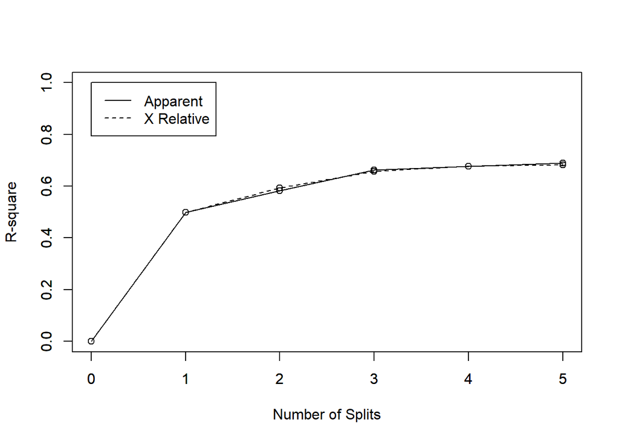

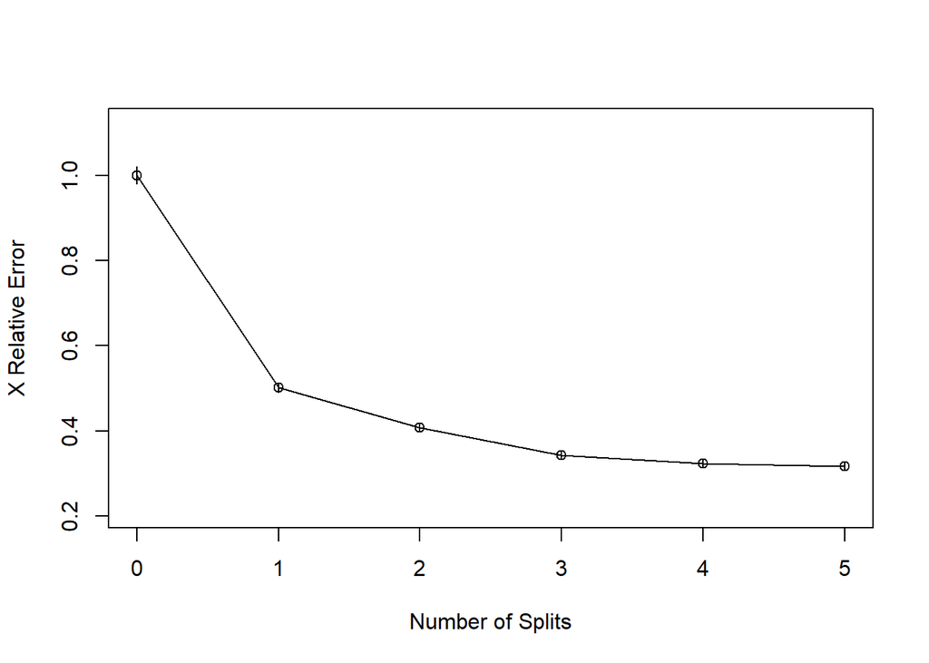

The column `CP` in the output is the complexity parameter that the model uses to determine when to split. It’s essentially the amount of change in $R^2$ that the algorithm requires to make a split.

From the `rpart` [documentation](https://cran.r-project.org/web/packages/rpart/vignettes/longintro.pdf):

> For regression models[…] the scaled cp has a very direct interpretation: if any split does not increase the overall R2 of the model by at least cp (where R2 is the usual linear-models definition) then that split is decreed to be, a priori, not worth pursuing. The program does not split said branch any further, and saves considerable computational effort. The default value of .01 has been reasonably successful at ‘pre-pruning’ trees so that the cross-validation step need only remove 1 or 2 layers, but it sometimes over prunes, particularly for large data sets.

One of the parameters that we can tweak to get a better fit is this `cp`.

## Pruning and tuning

As we’ve seen, tree models are also prone to overfitting the data. Consider again the big trees based on a complex model of genitive choice. These trees are far too complicated to interpret in any useful way.

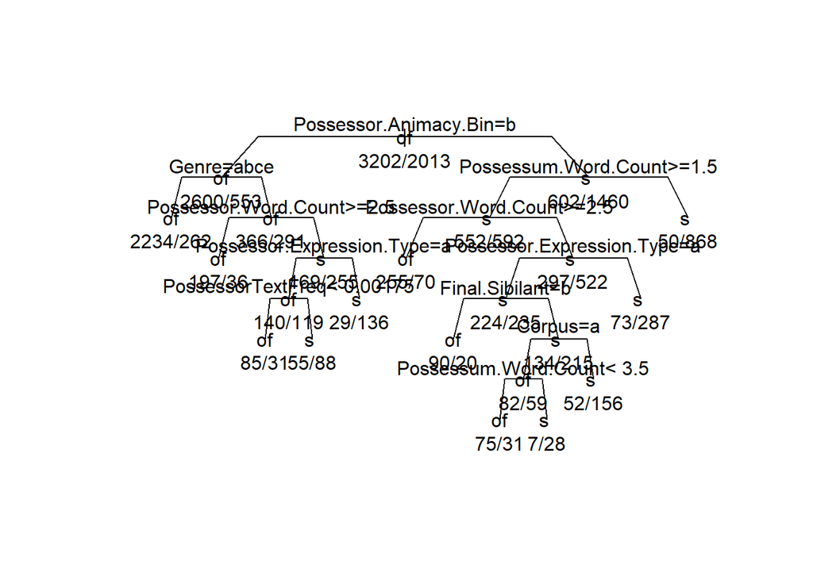

```r
# rpart
plot(gen_rpart2, uniform = T, branch = 0.8, margin = 0.1)
text(gen_rpart2, all = T, use.n = TRUE)
```

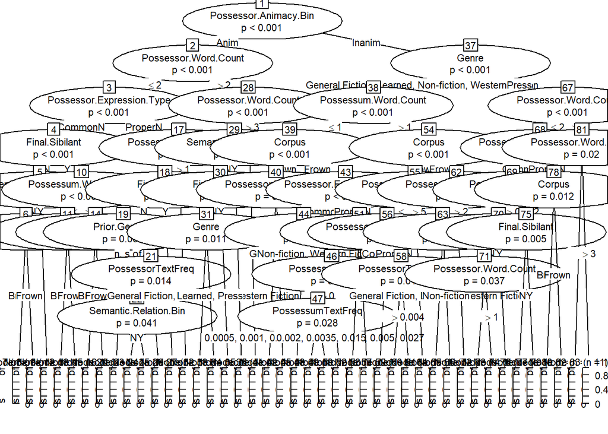

```r
# ctree
plot(gen_ctree2, gp = gpar(cex = 0.7))
```

### Pruning with `rpart`

Adjusting for overfitting can be done post-hoc by “pruning” the tree, or it can be done prior to fitting the model by tuning the control settings of the function beforehand. Pruning is important for CARTs fit with `rpart`, and this can be done with `prune()`. We inspect the `cp` parameter first with `printcp()` to see how much to prune by.

```r
printcp(gen_rpart2)
```

```
Classification tree:
rpart(formula = gen_fmla2, data = gens)

Variables actually used in tree construction:
[1] Corpus                    Final.Sibilant
[3] Genre                     Possessor.Animacy.Bin
[5] Possessor.Expression.Type Possessor.Word.Count
[7] PossessorTextFreq         Possessum.Word.Count

Root node error: 2013/5215 = 0.386

n= 5215

        CP nsplit rel error  xerror     xstd
1 0.426230      0   1.00000 1.00000 0.017465
2 0.045951      1   0.57377 0.57377 0.014896
3 0.021361      3   0.48187 0.48187 0.013959
4 0.017387      5   0.43915 0.44858 0.013574
5 0.013413      7   0.40437 0.41331 0.013136
6 0.011426      9   0.37755 0.38997 0.012828
7 0.010432     10   0.36612 0.38698 0.012788
8 0.010000     11   0.35569 0.38400 0.012747
```

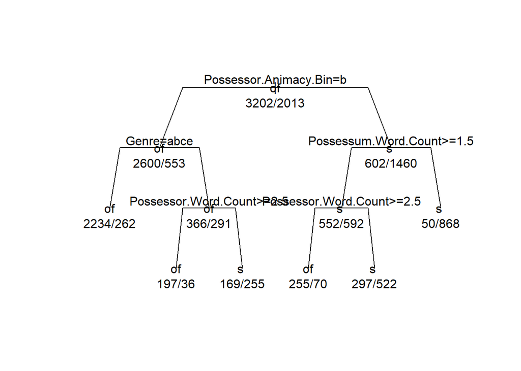

```r
gen_rpart2_pruned <- prune(gen_rpart2, cp = 0.02)
plot(gen_rpart2_pruned, uniform = T, branch = 0.8, margin = 0.1)
text(gen_rpart2_pruned, all = T, use.n = TRUE)
```

Pruning is generally not something that is done with ctrees (indeed, the technique was designed partly to make pruning unnecessary). What we should do instead, is decide how to control the growth of the tree beforehand in an unbiased way. There are a number of ways to do this.

### Adjusting *p*-value

One way is to adjust the **level of statistical significance** the tree requires a test to meet before making a split. Splits are only created when a global null hypothesis can reasonably be rejected, as determined by a chosen *p*-value (by default, this is the standard α = 0.05). You can adjust this under the `ctree_control()` options.

Let’s set it to require a *p*-value of 0.001 or below:

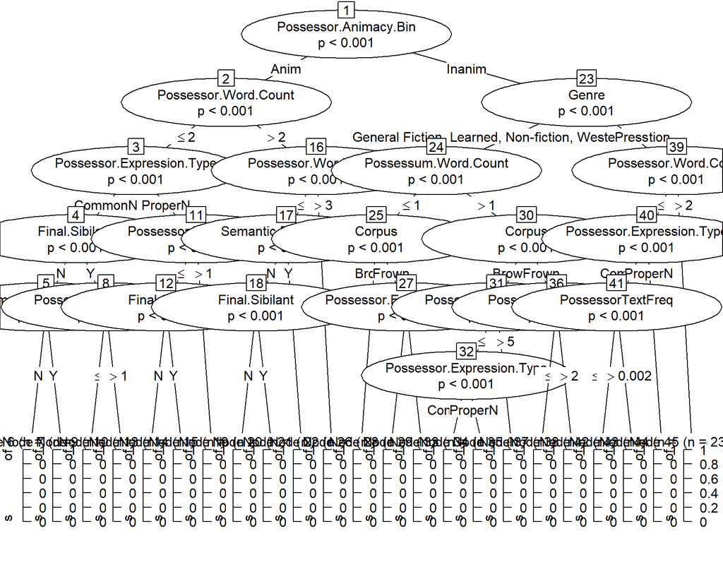

```r
gen_ctree2b <- ctree(gen_fmla2, data = gens, control = ctree_control(mincriterion = 0.999))  # now p < .001
# Note the value for 'mincriterion' is 1 minus the desired level: 1 - .001 =
# .999
plot(gen_ctree2b)
```

The tree is simpler now, but still pretty unmanageable.

### Limiting branching depth

Another way to simplify the tree is to limit the maximum depth of the branching with the `maxdepth` argument. The default is `maxdepth = Inf`, but you can tell it to stop splitting after a certain number of levels is reached.

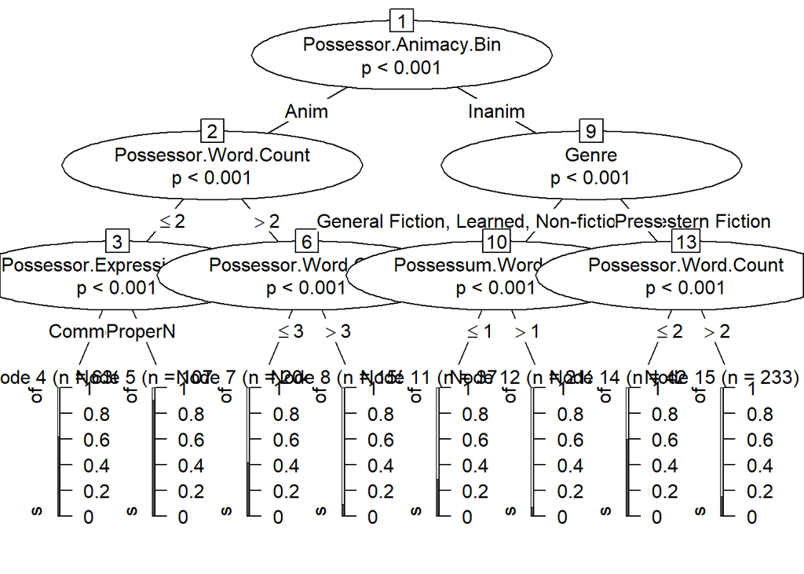

```r
gen_ctree2c <- ctree(gen_fmla2, data = gens, control = ctree_control(mincriterion = 0.999,
    maxdepth = 3))
plot(gen_ctree2c)
```

This is better, but we may be losing some predictive power. The tree is likely to make less accurate predictions, but it is at least interpretable.

### Adjusting for node size

We can alternatively specify the minimum number of observations in a node in order to consider a split. For instance, the following tree will not make a split unless there are more than 1000 observations in a node.

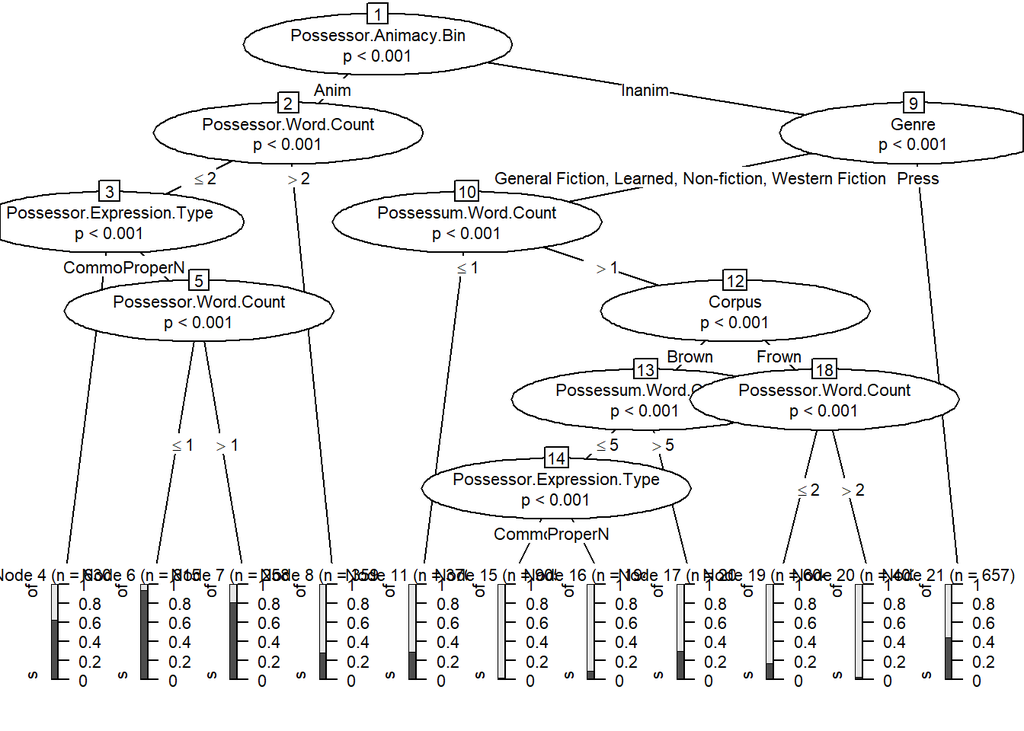

```r
gen_ctree2d <- ctree(gen_fmla2, data = gens, control = ctree_control(mincriterion = 0.999,
    minsplit = 1000L))
plot(gen_ctree2d, gp = gpar(cex = 0.7))
```

Or we can specify the minimum number of observations that must be present in a terminal (or more generally, any child) node. This tree will not make a split if it results in a subset with fewer than 200 observations.

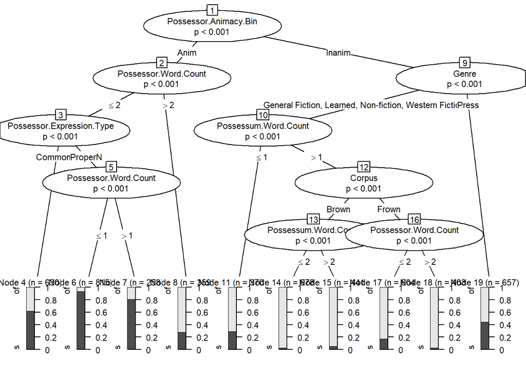

```r
gen_ctree2e <- ctree(gen_fmla2, data = gens, control = ctree_control(mincriterion = 0.999,
    minsplit = 1000L, minbucket = 200L))
plot(gen_ctree2e, gp = gpar(cex = 0.7))
```

These settings are designed to make the tree more *conservative* from an inferential point of view. Basically, it is more hesitant to make a claim about a given effect unless there is plenty of data that it can rely on.

Other options can be adjusted as needed/desired. See the documentation for `ctree` and `ctree_control` for how to do so.